# Analyse des facteurs influençant le loyer des logements à Dakar

Groupe X - Noms des membres

08 novembre 2025

# 1 Introduction

## 1.1 Contexte

Le marché immobilier de Dakar présente une grande hétérogénéité reflétant les disparités socio-économiques de la ville. Avec **41 logements** analysés, cette étude vise à comprendre les mécanismes de formation des prix.

## 1.2 Problématique

**Question centrale :** Quels sont les facteurs déterminants du prix de location des logements à Dakar ?

**Hypothèses à tester :**

1. Les caractéristiques physiques influencent le loyer
2. Le standing et l’état jouent un rôle significatif
3. La localisation est un facteur majeur
4. Les équipements impactent le prix
5. Le standing du quartier influe indépendamment

## 1.3 Objectifs

1. **Explorer** la distribution des loyers et identifier les segments
2. **Analyser** les relations entre loyer et facteurs explicatifs
3. **Quantifier** l’impact relatif de chaque variable
4. **Construire** un modèle prédictif robuste
5. **Proposer** des recommandations pratiques

# 2 Description des données

## 2.1 Présentation générale

Le jeu de données comprend **41 logements** décrits par **29 variables**.

Catégorisation des variables

| Catégorie | Variables | Nombre |
| --- | --- | --- |
| Identification | id | 1 |
| Prix | Loyer | 1 |
| Surfaces | SurfTerrain, SurfHabitable, SurfPiecResid | 3 |
| Composition | NbPieces, NbPiecesResid, NbSDB, NbChamBur, NbSalonsSAM, NbWC, NbCuis | 7 |
| Type & Standing | Type, Standing, StandingQuartier | 3 |
| État | Etat | 1 |
| Équipements | Jardin, Cour, Piscine, Garage, Egout, HiTech | 6 |
| Localisation | DistCtrVille, Commerc, BordMer, Distractions, AxeRoutier, QuartierAffaires, Quartier | 7 |

## 2.2 Aperçu des données

Échantillon de 10 logements

| ID | Loyer | Type | Surf. Terrain | Surf. Hab. | Pièces | Standing | État | Quartier | Bord Mer |
| --- | --- | --- | --- | --- | --- | --- | --- | --- | --- |
| 1 | 850 | Villa | 598 | 294 | 17 | Oui | Neuf | Mamelles | inf2km |
| 2 | 590 | Appart | 95 | 95 | 10 | Non | Bon | Plateau | sup2km |
| 3 | 200 | Appart | 90 | 90 | 9 | Oui | Vetuste | Mermoz | inf2km |
| 4 | 970 | Villa | 396 | 396 | 18 | Oui | Bon | Mamelles | inf2km |
| 5 | 600 | Villa | 589 | 251 | 14 | Oui | Mediocre | PointE | sup2km |
| 6 | 90 | Appart | 70 | 70 | 9 | Non | Mediocre | Medina | sup2km |
| 7 | 840 | Villa | 252 | 270 | 18 | Oui | Bon | FannHock | inf2km |
| 8 | 2 100 | Villa | 988 | 390 | 20 | Oui | Neuf | FannResidence | inf2km |
| 9 | 120 | Villa | 149 | 149 | 12 | Non | Mediocre | HLM | sup2km |
| 10 | 290 | Villa | 255 | 204 | 11 | Non | Bon | SacreCoeur | sup2km |

## 2.3 Statistiques descriptives

Statistiques des variables quantitatives

| Variable | N | Min | Q1 | Médiane | Moyenne | Q3 | Max | Écart-type |
| --- | --- | --- | --- | --- | --- | --- | --- | --- |
| Loyer | 41 | 20 | 60 | 190 | 356.0 | 440 | 2100 | 432.4 |
| NbChamBur | 41 | 1 | 3 | 4 | 4.1 | 6 | 10 | 2.2 |
| NbPieces | 41 | 3 | 8 | 10 | 11.0 | 14 | 20 | 4.5 |
| NbSDB | 41 | 1 | 1 | 2 | 1.9 | 2 | 4 | 0.8 |
| SurfHabitable | 41 | 19 | 69 | 129 | 154.2 | 220 | 396 | 105.0 |
| SurfTerrain | 41 | 19 | 69 | 101 | 196.6 | 255 | 988 | 196.6 |

# 3 Analyse univariée

## 3.1 Le loyer : variable cible

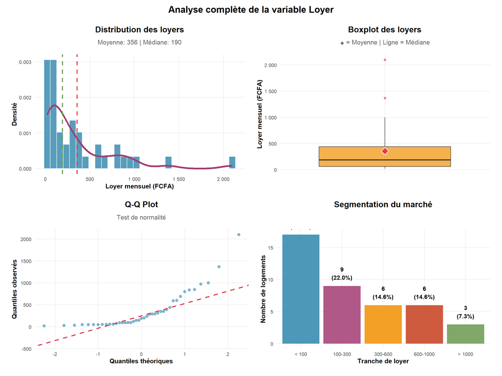

Statistiques descriptives du loyer

| Statistique | Valeur |
| --- | --- |
| Minimum | 20 |
| Q1 | 60 |
| Médiane | 190 |
| Moyenne | 356 |
| Q3 | 440 |
| Maximum | 2 100 |
| Écart_type | 432 |
| CV | 1.21 |

## 3.2 Surfaces

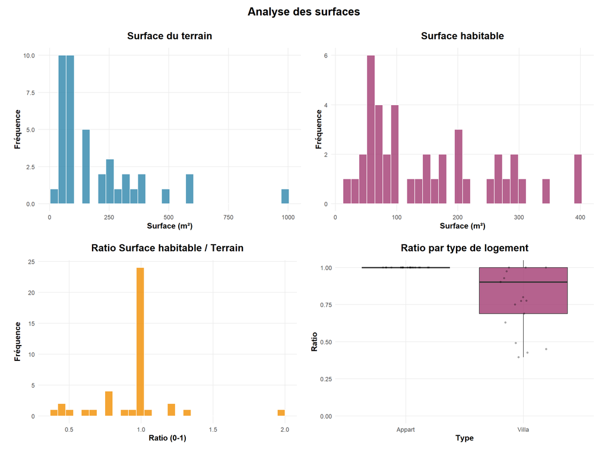

## 3.3 Type et standing

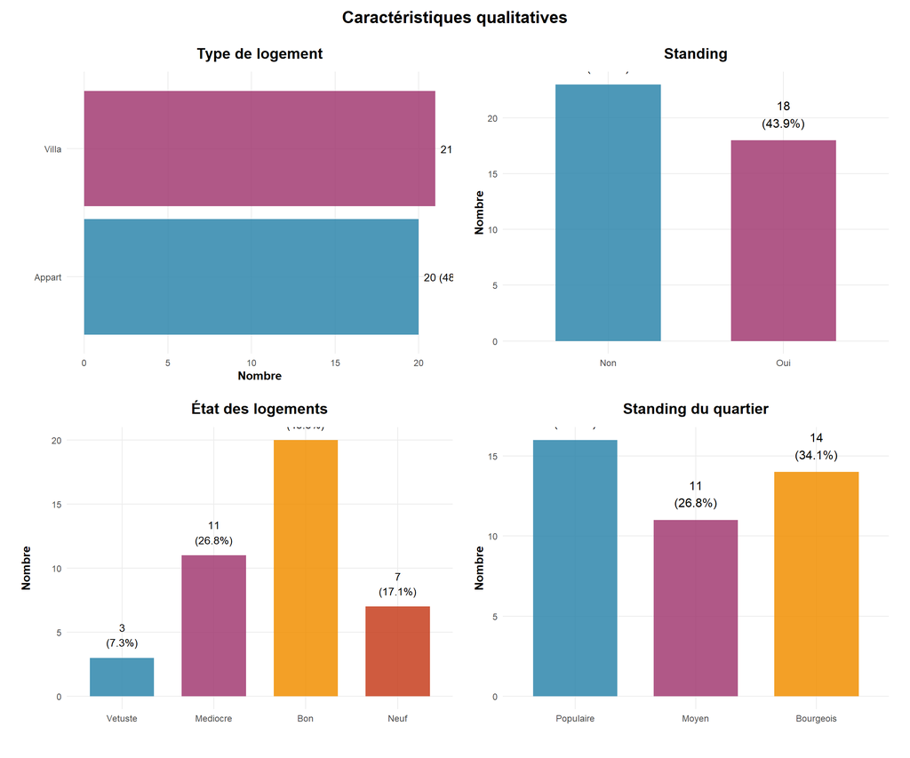

# 4 Analyse bivariée

## 4.1 Loyer vs Surfaces

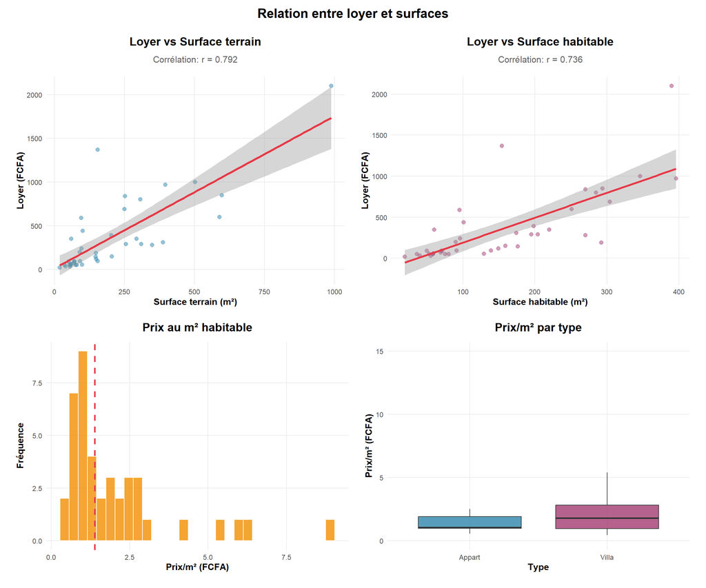

## 4.2 Loyer vs Type et Standing

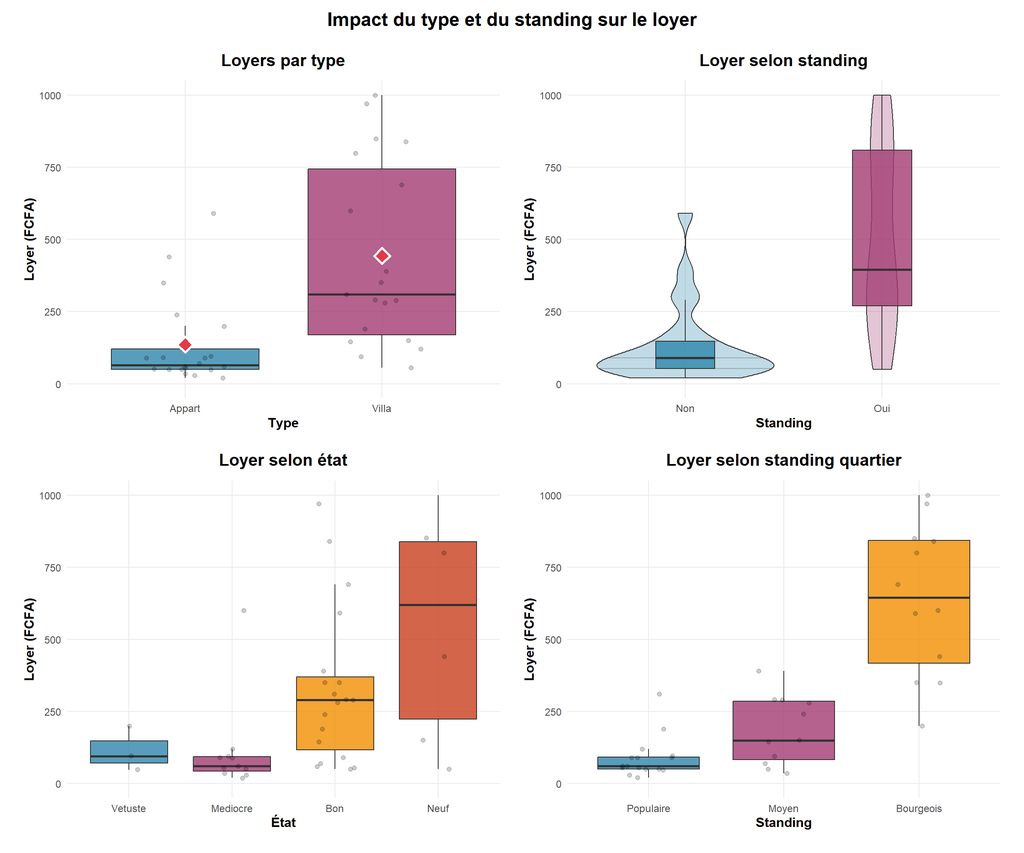

## 4.3 Matrice de corrélation

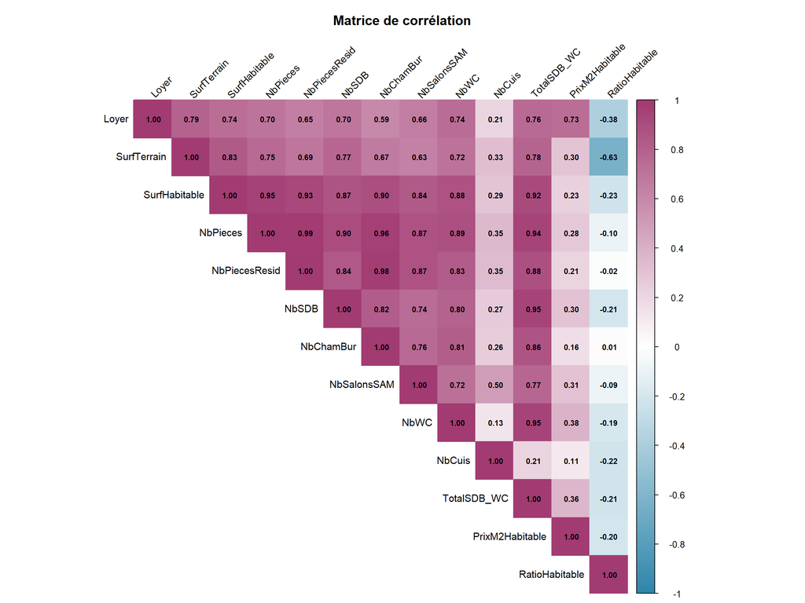

# 5 Tests statistiques

Tests ANOVA

Variable

F

P-value

η²

Signif.

StandingQuartier

24.11

1.73e-07

0.559

***

Garage

15.58

1.04e-06

0.558

***

Standing

20.25

5.97e-05

0.342

***

Etat

4.61

0.0077

0.272

Type

13.25

0.00079

0.254

***

Egout

8.48

0.00592

0.179

Jardin

7.05

0.0114

0.153

Piscine

6.36

0.0159

0.140

BordMer

6.22

0.0169

0.138

Note :

Significativité : *** p<0.001, ** p<0.01, * p<0.05, ns : non significatif

# 6 Modélisation

## 6.1 Modèle 1 : Régression simple

```
##
## Call:
## lm(formula = Loyer ~ SurfHabitable, data = dakar_clean)
##
## Residuals:
##     Min      1Q  Median      3Q     Max
## -583.73 -120.10  -16.49   52.20 1029.24
##
## Coefficients:
##                Estimate Std. Error t value Pr(>|t|)
## (Intercept)   -111.3108    83.0315  -1.341    0.188
## SurfHabitable    3.0310     0.4469   6.783 4.27e-08 ***
## ---
## Signif. codes:  0 '***' 0.001 '**' 0.01 '*' 0.05 '.' 0.1 ' ' 1
##
## Residual standard error: 296.6 on 39 degrees of freedom
## Multiple R-squared:  0.5412, Adjusted R-squared:  0.5294
## F-statistic:    46 on 1 and 39 DF,  p-value: 4.266e-08
```

**Interprétation :** R² = 0.541 - La surface habitable explique **54.1%** de la variance du loyer.

## 6.2 Modèle 2 : Caractéristiques physiques

```
##
## Call:
## lm(formula = Loyer ~ SurfHabitable + NbChamBur + NbSDB + Type,
##     data = dakar_clean)
##
## Residuals:
##     Min      1Q  Median      3Q     Max
## -482.86 -138.19  -50.81   42.08 1096.37
##
## Coefficients:
##               Estimate Std. Error t value Pr(>|t|)
## (Intercept)   -149.686    129.100  -1.159  0.25390
## SurfHabitable    4.359      1.336   3.264  0.00241 **
## NbChamBur      -73.151     49.074  -1.491  0.14477
## NbSDB          129.870    115.014   1.129  0.26630
## TypeVilla     -215.133    164.750  -1.306  0.19990
## ---
## Signif. codes:  0 '***' 0.001 '**' 0.01 '*' 0.05 '.' 0.1 ' ' 1
##
## Residual standard error: 285.7 on 36 degrees of freedom
## Multiple R-squared:  0.6071, Adjusted R-squared:  0.5634
## F-statistic:  13.9 on 4 and 36 DF,  p-value: 5.948e-07
```

Coefficients du Modèle 2

|  | Variable | Coefficient | Erreur std. | t | P-value | Signif. |
| --- | --- | --- | --- | --- | --- | --- |
| (Intercept) | (Intercept) | -149.69 | 129.10 | -1.16 | 0.25390 | ns |
| SurfHabitable | SurfHabitable | 4.36 | 1.34 | 3.26 | 0.00241 | ** |
| NbChamBur | NbChamBur | -73.15 | 49.07 | -1.49 | 0.14477 | ns |
| NbSDB | NbSDB | 129.87 | 115.01 | 1.13 | 0.26630 | ns |
| TypeVilla | TypeVilla | -215.13 | 164.75 | -1.31 | 0.19990 | ns |

## 6.3 Modèle 3 : Modèle complet

```
##
## Call:
## lm(formula = Loyer ~ SurfHabitable + NbChamBur + NbSDB + Type +
##     Standing + Etat + StandingQuartier + Piscine + Garage + BordMer,
##     data = dakar_clean)
##
## Residuals:
##     Min      1Q  Median      3Q     Max
## -437.94  -91.39   -7.91   62.28  736.25
##
## Coefficients:
##                           Estimate Std. Error t value Pr(>|t|)
## (Intercept)               -205.215    233.222  -0.880   0.3873
## SurfHabitable                2.074      1.936   1.071   0.2943
## NbChamBur                  -54.679     47.156  -1.160   0.2572
## NbSDB                      108.624    144.043   0.754   0.4578
## TypeVilla                   94.195    230.372   0.409   0.6861
## StandingOui                 34.464    155.657   0.221   0.8266
## EtatMediocre                60.856    192.329   0.316   0.7543
## EtatBon                    101.908    173.638   0.587   0.5625
## EtatNeuf                   259.381    198.892   1.304   0.2041
## StandingQuartierMoyen      -49.182    144.215  -0.341   0.7359
## StandingQuartierBourgeois  357.202    185.103   1.930   0.0651 .
## PiscineOui                -199.861    197.370  -1.013   0.3209
## GaragePark                -103.816    161.988  -0.641   0.5274
## GaragePriv1v              -138.154    240.035  -0.576   0.5701
## GaragePriv2v               100.274    337.469   0.297   0.7688
## BordMersup2km               71.345    109.082   0.654   0.5191
## ---
## Signif. codes:  0 '***' 0.001 '**' 0.01 '*' 0.05 '.' 0.1 ' ' 1
##
## Residual standard error: 255.1 on 25 degrees of freedom
## Multiple R-squared:  0.7826, Adjusted R-squared:  0.6522
## F-statistic:     6 on 15 and 25 DF,  p-value: 4.613e-05
```

Coefficients du Modèle 3

|  | Variable | Coefficient | Erreur std. | t | P-value | Signif. |
| --- | --- | --- | --- | --- | --- | --- |
| (Intercept) | (Intercept) | -205.21 | 233.22 | -0.88 | 0.3873 | ns |
| SurfHabitable | SurfHabitable | 2.07 | 1.94 | 1.07 | 0.2943 | ns |
| NbChamBur | NbChamBur | -54.68 | 47.16 | -1.16 | 0.2572 | ns |
| NbSDB | NbSDB | 108.62 | 144.04 | 0.75 | 0.4578 | ns |
| TypeVilla | TypeVilla | 94.20 | 230.37 | 0.41 | 0.6861 | ns |
| StandingOui | StandingOui | 34.46 | 155.66 | 0.22 | 0.8266 | ns |
| EtatMediocre | EtatMediocre | 60.86 | 192.33 | 0.32 | 0.7543 | ns |
| EtatBon | EtatBon | 101.91 | 173.64 | 0.59 | 0.5625 | ns |
| EtatNeuf | EtatNeuf | 259.38 | 198.89 | 1.30 | 0.2041 | ns |
| StandingQuartierMoyen | StandingQuartierMoyen | -49.18 | 144.22 | -0.34 | 0.7359 | ns |
| StandingQuartierBourgeois | StandingQuartierBourgeois | 357.20 | 185.10 | 1.93 | 0.0651 | ns |
| PiscineOui | PiscineOui | -199.86 | 197.37 | -1.01 | 0.3209 | ns |
| GaragePark | GaragePark | -103.82 | 161.99 | -0.64 | 0.5274 | ns |
| GaragePriv1v | GaragePriv1v | -138.15 | 240.03 | -0.58 | 0.5701 | ns |
| GaragePriv2v | GaragePriv2v | 100.27 | 337.47 | 0.30 | 0.7688 | ns |
| BordMersup2km | BordMersup2km | 71.34 | 109.08 | 0.65 | 0.5191 | ns |

## 6.4 Comparaison des modèles

Comparaison des trois modèles

| Modèle | Variables | Nb param. | R² | R² ajusté | RMSE | AIC | BIC |
| --- | --- | --- | --- | --- | --- | --- | --- |
| Modèle 1: Simple | SurfHabitable seule | 2 | 0.5412 | 0.5294 | 289.3 | 587.1 | 592.2 |
| Modèle 2: Physique | Surfaces + Composition + Type | 5 | 0.6071 | 0.5634 | 267.8 | 586.7 | 597.0 |
| Modèle 3: Complet | Toutes variables pertinentes | 16 | 0.7826 | 0.6522 | 199.2 | 584.5 | 613.6 |

## 6.5 Diagnostics du modèle final

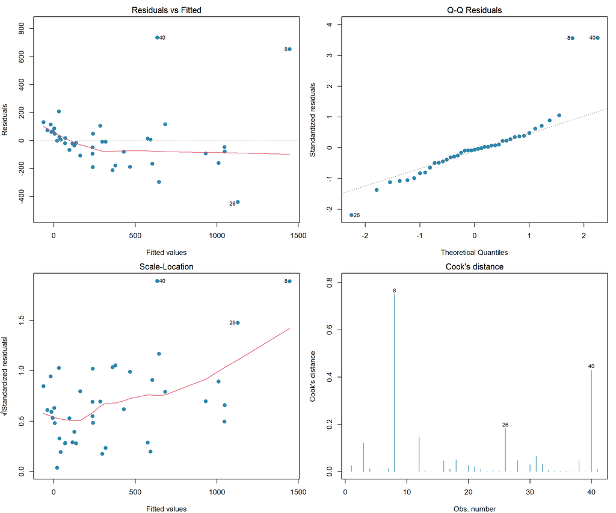

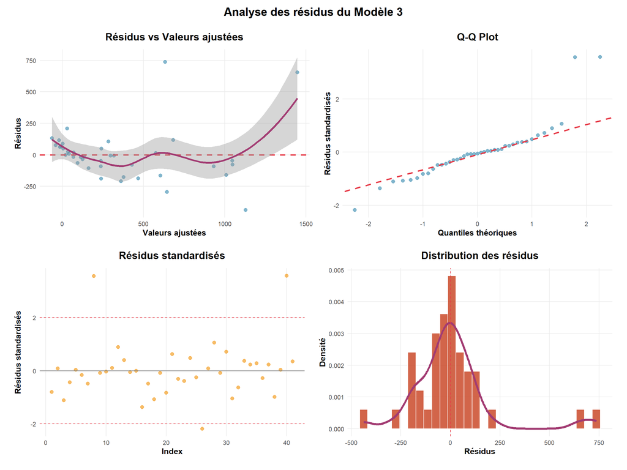

## 6.6 Prédictions et performance

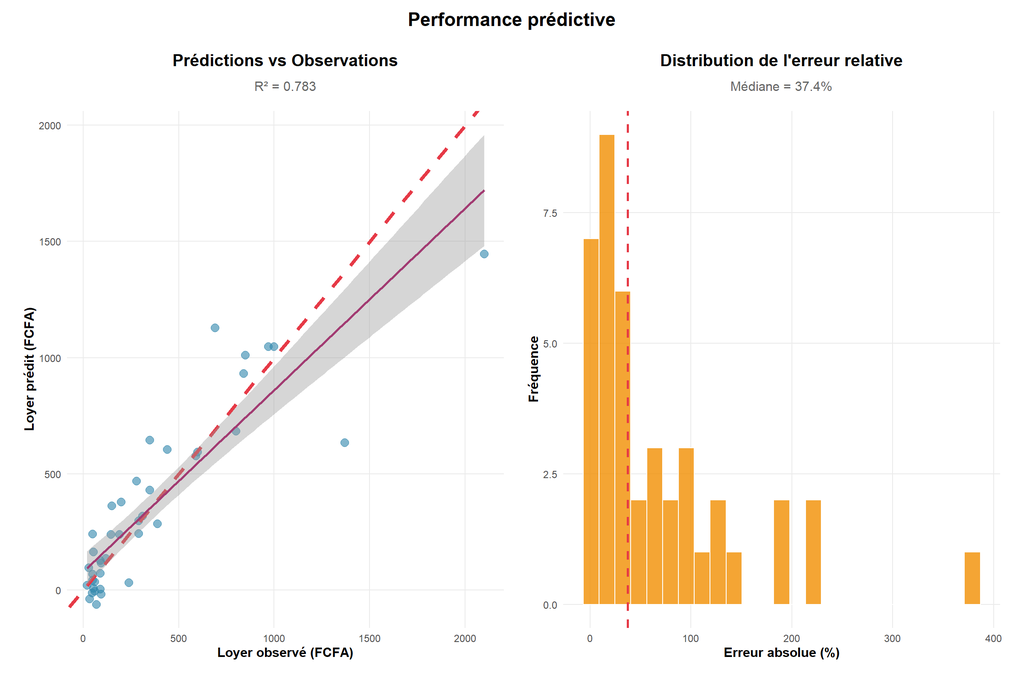

Métriques de performance

| Métrique | Valeur | Interprétation |
| --- | --- | --- |
| R² | 0.78 | 78.3% de variance expliquée |
| R² ajusté | 0.65 | 65.2% ajusté |
| RMSE | 199.16 | Erreur quadratique moyenne |
| MAE | 123.52 | Erreur absolue moyenne |
| MAPE | 68.42 | Erreur relative moyenne |
| Médiane Err. % | 37.44 | Erreur relative médiane |

# 7 Conclusions

## 7.1 Synthèse des résultats

### 7.1.2 Segmentation du marché

Segments de marché

| Segment | N | Loyer moyen | Loyer médian | Surf. moy. | % Standing | % Piscine |
| --- | --- | --- | --- | --- | --- | --- |
| Haut standing | 9 | 1024 | 850 | 299 | 100.0 | 44.4 |
| Moyen standing | 11 | 339 | 310 | 155 | 63.6 | 0.0 |
| Économique | 21 | 78 | 60 | 92 | 9.5 | 0.0 |

## 7.2 Limites de l’analyse

### 7.2.1 Limitations des données

- **Taille échantillon** : 41 observations
- **Variables manquantes** : Année de construction, finitions
- **Absence temporelle** : Pas d’évolution temporelle
- **Valeurs manquantes** : Sur certaines variables dérivées

### 7.2.2 Limitations statistiques

- **Hétéroscédasticité** : Variance non constante
- **Non-normalité** : Résidus avec queue lourde
- **Multicolinéarité** : Entre variables de composition
- **Points influents** : Observations à fort levier

### 7.2.3 Recommandations méthodologiques

- **Transformation log** pour normaliser
- **Modèles robustes** aux outliers
- **Interactions** à tester
- **Validation croisée**

## 7.3 Recommandations pratiques

### 7.3.2 Pour les locataires

🏠 **Optimiser le rapport qualité/prix :**

- Quartiers moyens : bon compromis
- Appartements : meilleur prix/m²
- Négocier équipements non nécessaires
- État “Bon” vs “Neuf”

### 7.3.3 Pour décideurs publics

🏛️ **Politique d’aménagement :**

- Développer infrastructures quartiers populaires
- Encourager logements intermédiaires
- Surveiller zones en gentrification
- Créer observatoire des loyers

## 7.4 Perspectives

### 7.4.1 Améliorations court terme

1. Augmenter l’échantillon (>1000 logements)
2. Variables complémentaires (année, charges)
3. Géolocalisation GPS
4. Série temporelle

### 7.4.2 Développements avancés

Perspectives de développement

| Axe | Propositions |
| --- | --- |
| Modélisation | Random Forest, XGBoost, GAM |
| Données | Web scraping, API géographiques |
| Outils | Shiny dashboard, API prédiction |
| Application | Simulateur rénovations, estimateur |